# Efeito da Lei 13.811/2019 sobre Casamento Infantil — Painel de Capitais

DiD agregado, eixo PNADC (prevalência de união por capital)

25 de agosto de 2026

## Contexto

Esta análise complementa o desenho individual (`10_inf_causal.Rmd`) agregando os dados a nível de **capital**, eixo **PNADC**: prevalência de união (formal + informal) por capital, obtida via peso amostral (`pes_comcalib`). Só existe nos anos com PNADC (2012–2019, 2022–2025) e só nas 27 capitais (a PNADC não identifica outros municípios).

O eixo Registro Civil (capitais e municípios) foi desenvolvido em paralelo, mas está fora do escopo deste relatório por enquanto — o foco atual é fechar o eixo PNADC-capitais antes de retomá-lo.

**Unidade do painel:** diferente do desenho individual, aqui cada “indivíduo” do `att_gt()` é uma célula (capital) × grupo etário, observada ano a ano — um painel de verdade (`panel=TRUE`), não corte repetido. As estimativas são ponderadas pelo tamanho populacional da capital (`weightsname = "pop_estimada"`), para que capitais pequenas e ruidosas pesem menos que as grandes.

**Grupos etários** (mesmos do desenho individual): tratada 14–15, controle principal 16–17, controle de robustez 17–18. “17 anos” pertence aos dois grupos de controle, então cada comparação é rodada separadamente.

**Correção aplicada durante a construção deste painel:**

- **Numerador de união PNADC ampliado**: a definição original só capturava meninas registradas como *cônjuge*; meninas que são *chefes* de domicílio com cônjuge adulto do sexo oposto (categoria B do `categ_domic` nacional) ficavam de fora. Corrigido para capturar os dois papéis.

**Limitação que permanece:**

- Duas células do painel (RJ 2023 e AM 2019, ambas no grupo 17-18) são anomalias estatisticamente genuínas — zero casos de união apesar de amostra grande o suficiente pra isso ser improvável por acaso, e isoladas na série histórica daquela capital (ver Bloco 2A).

## Prevalências Absolutas por Grupo Etário

O ATT é uma **diferença de diferenças** — não mostra, por si só, se o grupo tratado subiu ou se o grupo de controle caiu. Os gráficos abaixo mostram o **nível absoluto** da taxa de união (agregada nas 27 capitais, ponderada por população) para cada grupo etário, ano a ano, antes de qualquer diferenciação. Servem para checar, visualmente, qual dos dois lados está efetivamente se movendo.

### Principal e robustez (14-15 vs 16-17 vs 17-18)

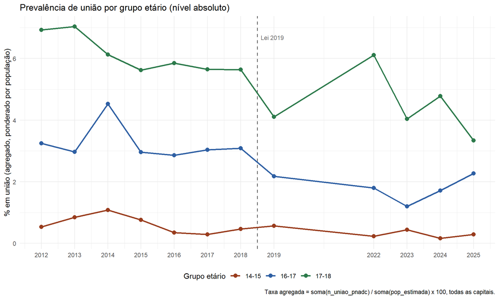

```r
fig_niveis_absolutos(painel_capital_taxas, c("14-15", "16-17", "17-18"),
                     "Prevalência de união por grupo etário (nível absoluto)")
```

### Placebo e grupo exploratório (16-17 vs 17-18 vs 15-16)

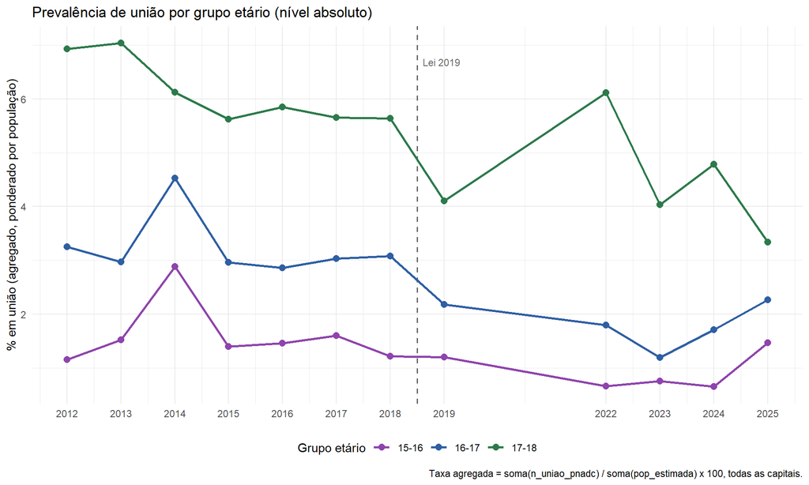

```r
fig_niveis_absolutos(painel_capital_taxas, c("15-16", "16-17", "17-18"),
                     "Prevalência de união por grupo etário (nível absoluto)")
```

## Bloco 0 — Especificação do Modelo

**Estimador:** Callaway & Sant’Anna (2021), via `did::att_gt()` — mesmo estimador e mesmo pacote do desenho individual nacional (`10_inf_causal.Rmd`).

```r
tibble::tribble(
  ~Parâmetro,        ~Valor,               ~Significado,
  "Estimador",        "did::att_gt()",      "Callaway & Sant'Anna (2021)",
  "panel",             "TRUE",               "Painel verdadeiro (mesma capital-grupo todo ano)",
  "weightsname",       "\"pop_estimada\"",   "Ponderado por população da capital",
  "base_period",       "\"universal\"",      "Ano de referência ÚNICO (2018) -- não é média do pré",
  "control_group",     "\"nevertreated\"",   "Controle = grupo nunca diretamente afetado pela lei",
  "bstrap",            "FALSE",              "Erro padrão analítico, sem bootstrap",
  "cband",             "FALSE",              "Sem banda de confiança uniforme (simultânea)",
  "Agregação (ATT)",   "aggte(type=\"simple\")",  "ATT geral pós-2019",
  "Agregação (evento)","aggte(type=\"dynamic\")", "Event-study ano a ano"
) |>
  knitr::kable(caption = "Parâmetros da especificação principal (Bloco 1).")
```

Parâmetros da especificação principal (Bloco 1).

| Parâmetro | Valor | Significado |
| --- | --- | --- |
| Estimador | did::att_gt() | Callaway & Sant’Anna (2021) |
| panel | TRUE | Painel verdadeiro (mesma capital-grupo todo ano) |
| weightsname | “pop_estimada” | Ponderado por população da capital |
| base_period | “universal” | Ano de referência ÚNICO (2018) – não é média do pré |
| control_group | “nevertreated” | Controle = grupo nunca diretamente afetado pela lei |
| bstrap | FALSE | Erro padrão analítico, sem bootstrap |
| cband | FALSE | Sem banda de confiança uniforme (simultânea) |
| Agregação (ATT) | aggte(type=“simple”) | ATT geral pós-2019 |
| Agregação (evento) | aggte(type=“dynamic”) | Event-study ano a ano |

**Grupos etários:**

```r
tibble::tribble(
  ~Papel,               ~Grupo,   ~Idades,
  "Tratada",            "14-15",  "14 e 15 anos",
  "Controle principal", "16-17",  "16 e 17 anos",
  "Controle robustez",  "17-18",  "17 e 18 anos"
) |>
  knitr::kable(caption = "Grupos etários usados nas três comparações do Bloco 1.")
```

Grupos etários usados nas três comparações do Bloco 1.

| Papel | Grupo | Idades |
| --- | --- | --- |
| Tratada | 14-15 | 14 e 15 anos |
| Controle principal | 16-17 | 16 e 17 anos |
| Controle robustez | 17-18 | 17 e 18 anos |

**Nota:** a “média do período pré-tratamento” (Bloco 2B) **não** é a especificação principal – é um teste de robustez à parte, estimado via `fixest::feols()` sobre os dados colapsados em 2 períodos, não via `att_gt()`. A especificação principal usa `base_period="universal"` (2018 como único ano de referência).

## Bloco 1 — Eixo PNADC (Capitais)

Outcome: `taxa_pnadc_pct` — % de meninas daquela idade em união (formal ou informal), segundo a PNADC.

### Principal (14-15 vs 16-17)

#### Código

```r
dados_spec <- painel_capital_taxas |>
  filter(grupo_etario %in% c("14-15", "16-17")) |>
  mutate(
    D    = as.integer(grupo_etario == "14-15"),
    G    = if_else(D == 1L, 2019, 0),
    id   = as.integer(factor(paste(cod_mun, grupo_etario, sep = "_"))),
    ano  = as.integer(ano)
  ) |>
  as.data.frame()

cs_pnadc_1617 <- att_gt(
  yname         = "taxa_pnadc_pct",
  tname         = "ano",
  idname        = "id",
  gname         = "G",
  data          = dados_spec,
  panel         = TRUE,
  weightsname   = "pop_estimada",
  control_group = "nevertreated",
  base_period   = "universal",
  bstrap        = FALSE,
  cband         = FALSE
)

aggte(cs_pnadc_1617, type = "simple")    # ATT geral pós-2019
aggte(cs_pnadc_1617, type = "dynamic")   # event study
```

#### Resultados

```r
r <- reporta_bloco(cs_pnadc_1617, "pp")
if (!is.null(r))
  tab_att_pp("PNADC Capitais — 14-15 vs 16-17", r$att, r$se, r$pval, r$unidade) |>
    knitr::kable(caption = "ATT geral pós-2019.", align = "lrrrrrrl")
```

ATT geral pós-2019.

| Estimador | ATT | SE | p-valor | Sig | IC inf | IC sup | Unidade |
| --- | --- | --- | --- | --- | --- | --- | --- |
| PNADC Capitais — 14-15 vs 16-17 | 1.0073 | 0.4293 | 0.0189 | ** | 0.166 | 1.849 | pp |

```r
if (!is.null(cs_pnadc_1617))
  tab_event_study_pp(aggte(cs_pnadc_1617, type = "dynamic", na.rm = TRUE)) |>
    knitr::kable(caption = "Event study — valores em pp.", align = "rrrrrrl")
```

Event study — valores em pp.

| e | Ano | ATT | SE | IC inf | IC sup | Período |
| --- | --- | --- | --- | --- | --- | --- |
| -7 | 2012 | -0.0668 | 0.5776 | -1.199 | 1.065 | Pré |
| -6 | 2013 | 0.3851 | 1.0513 | -1.675 | 2.446 | Pré |
| -5 | 2014 | -0.8084 | 0.9289 | -2.629 | 1.012 | Pré |
| -4 | 2015 | 0.1226 | 1.0701 | -1.975 | 2.220 | Pré |
| -3 | 2016 | 0.1502 | 0.6287 | -1.082 | 1.382 | Pré |
| -2 | 2017 | -0.1112 | 0.6518 | -1.389 | 1.166 | Pré |
| -1 | 2018 | 0.0000 | NA | NA | NA | Pré |
| 0 | 2019 | 1.0855 | 0.6454 | -0.179 | 2.350 | Pós |
| 3 | 2022 | 1.0208 | 0.7018 | -0.355 | 2.396 | Pós |
| 4 | 2023 | 1.8057 | 0.6169 | 0.597 | 3.015 | Pós |
| 5 | 2024 | 1.1247 | 0.5276 | 0.091 | 2.159 | Pós |
| 6 | 2025 | 0.0000 | NA | NA | NA | Pós |

#### Figura

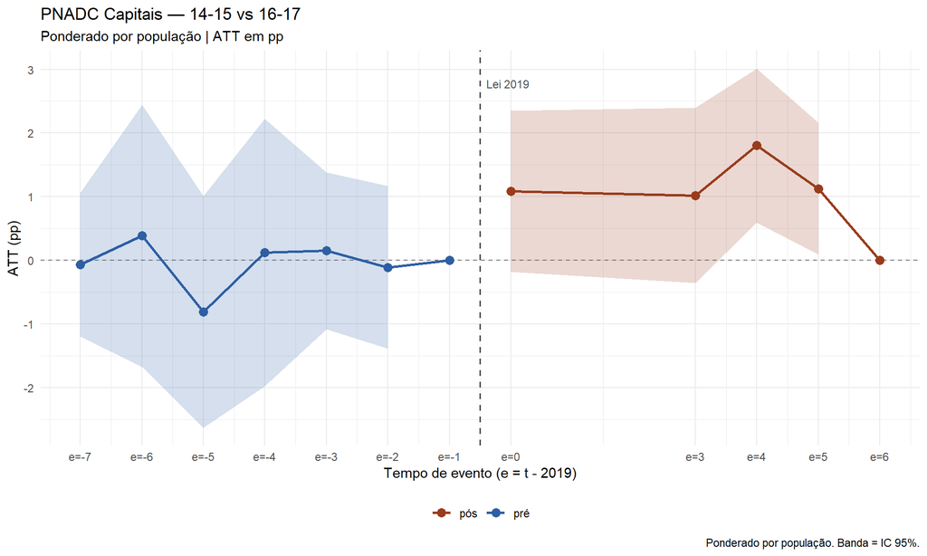

```r
fig_event_study(cs_pnadc_1617,
                 "PNADC Capitais — 14-15 vs 16-17",
                 "Ponderado por população | ATT em pp", "ATT (pp)")
```

### Robustez (14-15 vs 17-18)

#### Código

```r
dados_spec <- painel_capital_taxas |>
  filter(grupo_etario %in% c("14-15", "17-18")) |>
  mutate(
    D    = as.integer(grupo_etario == "14-15"),
    G    = if_else(D == 1L, 2019, 0),
    id   = as.integer(factor(paste(cod_mun, grupo_etario, sep = "_"))),
    ano  = as.integer(ano)
  ) |>
  as.data.frame()

cs_pnadc_1718 <- att_gt(
  yname         = "taxa_pnadc_pct",
  tname         = "ano",
  idname        = "id",
  gname         = "G",
  data          = dados_spec,
  panel         = TRUE,
  weightsname   = "pop_estimada",
  control_group = "nevertreated",
  base_period   = "universal",
  bstrap        = FALSE,
  cband         = FALSE
)

aggte(cs_pnadc_1718, type = "simple")
aggte(cs_pnadc_1718, type = "dynamic")
```

#### Resultados

```r
r <- reporta_bloco(cs_pnadc_1718, "pp")
if (!is.null(r))
  tab_att_pp("PNADC Capitais — 14-15 vs 17-18", r$att, r$se, r$pval, r$unidade) |>
    knitr::kable(caption = "ATT geral pós-2019.", align = "lrrrrrrl")
```

ATT geral pós-2019.

| Estimador | ATT | SE | p-valor | Sig | IC inf | IC sup | Unidade |
| --- | --- | --- | --- | --- | --- | --- | --- |
| PNADC Capitais — 14-15 vs 17-18 | 0.7222 | 0.4918 | 0.142 |  | -0.242 | 1.686 | pp |

```r
if (!is.null(cs_pnadc_1718))
  tab_event_study_pp(aggte(cs_pnadc_1718, type = "dynamic", na.rm = TRUE)) |>
    knitr::kable(caption = "Event study — valores em pp.", align = "rrrrrrl")
```

Event study — valores em pp.

| e | Ano | ATT | SE | IC inf | IC sup | Período |
| --- | --- | --- | --- | --- | --- | --- |
| -7 | 2012 | -1.1062 | 0.9463 | -2.961 | 0.749 | Pré |
| -6 | 2013 | -1.1680 | 1.2823 | -3.681 | 1.345 | Pré |
| -5 | 2014 | -0.0214 | 1.3102 | -2.589 | 2.547 | Pré |
| -4 | 2015 | 0.0936 | 1.2566 | -2.369 | 2.557 | Pré |
| -3 | 2016 | -0.3440 | 0.9096 | -2.127 | 1.439 | Pré |
| -2 | 2017 | -0.0113 | 0.6760 | -1.336 | 1.314 | Pré |
| -1 | 2018 | 0.0000 | NA | NA | NA | Pré |
| 0 | 2019 | 1.6863 | 0.9135 | -0.104 | 3.477 | Pós |
| 3 | 2022 | -0.6694 | 0.7930 | -2.224 | 0.885 | Pós |
| 4 | 2023 | 1.7985 | 0.8903 | 0.054 | 3.543 | Pós |
| 5 | 2024 | 0.7955 | 0.9087 | -0.986 | 2.577 | Pós |
| 6 | 2025 | 0.0000 | NA | NA | NA | Pós |

#### Figura

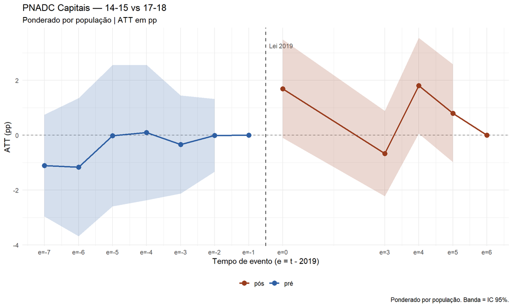

```r
fig_event_study(cs_pnadc_1718,
                 "PNADC Capitais — 14-15 vs 17-18",
                 "Ponderado por população | ATT em pp", "ATT (pp)")
```

### Placebo (16-17 vs 17-18)

#### Código

```r
dados_spec <- painel_capital_taxas |>
  filter(grupo_etario %in% c("16-17", "17-18")) |>
  mutate(
    D    = as.integer(grupo_etario == "16-17"),
    G    = if_else(D == 1L, 2019, 0),
    id   = as.integer(factor(paste(cod_mun, grupo_etario, sep = "_"))),
    ano  = as.integer(ano)
  ) |>
  as.data.frame()

cs_pnadc_pb <- att_gt(
  yname         = "taxa_pnadc_pct",
  tname         = "ano",
  idname        = "id",
  gname         = "G",
  data          = dados_spec,
  panel         = TRUE,
  weightsname   = "pop_estimada",
  control_group = "nevertreated",
  base_period   = "universal",
  bstrap        = FALSE,
  cband         = FALSE
)

aggte(cs_pnadc_pb, type = "simple")
aggte(cs_pnadc_pb, type = "dynamic")
```

#### Resultados

```r
r <- reporta_bloco(cs_pnadc_pb, "pp")
if (!is.null(r))
  tab_att_pp("PNADC Capitais — Placebo 16-17 vs 17-18", r$att, r$se, r$pval, r$unidade) |>
    knitr::kable(caption = "ATT geral pós-2019. Nenhum dos dois grupos é afetado pela lei.", align = "lrrrrrrl")
```

ATT geral pós-2019. Nenhum dos dois grupos é afetado pela lei.

| Estimador | ATT | SE | p-valor | Sig | IC inf | IC sup | Unidade |
| --- | --- | --- | --- | --- | --- | --- | --- |
| PNADC Capitais — Placebo 16-17 vs 17-18 | -0.2852 | 0.601 | 0.6351 |  | -1.463 | 0.893 | pp |

```r
if (!is.null(cs_pnadc_pb))
  tab_event_study_pp(aggte(cs_pnadc_pb, type = "dynamic", na.rm = TRUE)) |>
    knitr::kable(caption = "Event study — valores em pp.", align = "rrrrrrl")
```

Event study — valores em pp.

| e | Ano | ATT | SE | IC inf | IC sup | Período |
| --- | --- | --- | --- | --- | --- | --- |
| -7 | 2012 | -1.0394 | 1.0733 | -3.143 | 1.064 | Pré |
| -6 | 2013 | -1.5531 | 1.5699 | -4.630 | 1.524 | Pré |
| -5 | 2014 | 0.7870 | 1.5679 | -2.286 | 3.860 | Pré |
| -4 | 2015 | -0.0290 | 1.5802 | -3.126 | 3.068 | Pré |
| -3 | 2016 | -0.4943 | 1.0514 | -2.555 | 1.566 | Pré |
| -2 | 2017 | 0.0998 | 0.8728 | -1.611 | 1.810 | Pré |
| -1 | 2018 | 0.0000 | NA | NA | NA | Pré |
| 0 | 2019 | 0.6008 | 1.0431 | -1.444 | 2.645 | Pós |
| 3 | 2022 | -1.6902 | 1.0097 | -3.669 | 0.289 | Pós |
| 4 | 2023 | -0.0072 | 0.9700 | -1.908 | 1.894 | Pós |
| 5 | 2024 | -0.3292 | 1.0025 | -2.294 | 1.636 | Pós |
| 6 | 2025 | 0.0000 | NA | NA | NA | Pós |

#### Figura

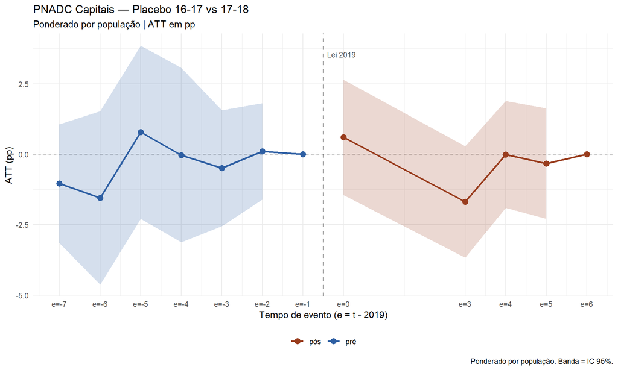

```r
fig_event_study(cs_pnadc_pb,
                 "PNADC Capitais — Placebo 16-17 vs 17-18",
                 "Ponderado por população | ATT em pp", "ATT (pp)")
```

## Sumário Comparativo

```r
r1 <- reporta_bloco(cs_pnadc_1617,  "pp")
r2 <- reporta_bloco(cs_pnadc_1718,  "pp")
r3 <- reporta_bloco(cs_pnadc_pb,    "pp")

linhas <- list(
  list("PNADC Capitais — 14-15 vs 16-17",       r1),
  list("PNADC Capitais — 14-15 vs 17-18",       r2),
  list("PNADC Capitais — Placebo",              r3)
)

purrr::map_dfr(linhas, function(x) {
  if (is.null(x[[2]])) return(tibble::tibble())
  tab_att_pp(x[[1]], x[[2]]$att, x[[2]]$se, x[[2]]$pval, x[[2]]$unidade)
}) |>
  knitr::kable(
    caption = "Sumário dos DiDs de capitais (eixo PNADC). *** p<0.01  ** p<0.05  * p<0.10.",
    align = "lrrrrrrl"
  )
```

Sumário dos DiDs de capitais (eixo PNADC). *** p<0.01 ** p<0.05 * p<0.10.

| Estimador | ATT | SE | p-valor | Sig | IC inf | IC sup | Unidade |
| --- | --- | --- | --- | --- | --- | --- | --- |
| PNADC Capitais — 14-15 vs 16-17 | 1.0073 | 0.4293 | 0.0189 | ** | 0.166 | 1.849 | pp |
| PNADC Capitais — 14-15 vs 17-18 | 0.7222 | 0.4918 | 0.1420 |  | -0.242 | 1.686 | pp |
| PNADC Capitais — Placebo | -0.2852 | 0.6010 | 0.6351 |  | -1.463 | 0.893 | pp |

**Comparação de referência — desenho individual nacional (10_inf_causal.Rmd):**

| Especificação | ATT | SE | p |
| --- | --- | --- | --- |
| DR-DiD 14-15 vs 16-17 | +0.619 pp | 0.348 | 0.076 |
| DR-DiD 14-15 vs 17-18 | +1.888 pp | 0.452 | <0.001 |
| Placebo 16-17 vs 17-18 | +2.084 pp | 0.735 | 0.005 |

## Bloco 2 — Testes de Robustez Adicionais (eixo PNADC, capitais)

Quatro testes sobre o painel de capitais, depois das correções acima: diagnóstico de zeros, baseline alternativa, com/sem peso, e um grupo etário adicional (15-16 como tratado). Ver `20_testes_robustez_capital.R`.

### A) Diagnóstico de zeros

Compara o N bruto (não ponderado) de meninas em união com o N bruto do denominador (todas as meninas daquela idade, em união ou não), para separar zeros esperados (evento raro + amostra pequena) de zeros estatisticamente improváveis.

```r
if (!is.null(testes_robustez)) {
  diag <- testes_robustez$diag_zeros
  resumo <- diag |>
    dplyr::group_by(grupo_etario) |>
    dplyr::summarise(
      `% células zero`      = round(mean(n_bruto == 0) * 100, 1),
      `Taxa média (%)`      = round(100 * sum(n_bruto) / sum(n_bruto_pop), 3),
      .groups = "drop"
    )
  knitr::kable(resumo, caption = "Taxa de zeros e incidência média por grupo etário.")
}
```

Taxa de zeros e incidência média por grupo etário.

| grupo_etario | % células zero | Taxa média (%) |
| --- | --- | --- |
| 14-15 | 88.0 | 0.631 |
| 15-16 | 51.5 | 1.537 |
| 16-17 | 62.7 | 3.110 |
| 17 | 43.2 | 3.908 |
| 17-18 | 55.0 | 5.903 |

```r
if (!is.null(testes_robustez)) {
  zeros_susp <- testes_robustez$diag_zeros |>
    dplyr::filter(n_bruto == 0, prob_zero_esperada < 0.05) |>
    dplyr::arrange(prob_zero_esperada) |>
    dplyr::select(capital_nome, uf, ano, grupo_etario, n_bruto_pop, prob_zero_esperada)
  knitr::kable(zeros_susp,
    caption = "Células com zero estatisticamente improvável (<5% de chance por acaso).")
}
```

Células com zero estatisticamente improvável (<5% de chance por acaso).

| capital_nome | uf | ano | grupo_etario | n_bruto_pop | prob_zero_esperada |
| --- | --- | --- | --- | --- | --- |
| Rio de Janeiro | RJ | 2023 | 17-18 | 114 | 0.0009722 |
| Manaus | AM | 2019 | 17-18 | 105 | 0.0016809 |
| Belém | PA | 2014 | 17-18 | 72 | 0.0125175 |
| São Paulo | SP | 2015 | 16-17 | 122 | 0.0211819 |
| Belém | PA | 2015 | 17-18 | 62 | 0.0230013 |
| Brasília | DF | 2023 | 16-17 | 106 | 0.0351164 |
| Rio de Janeiro | RJ | 2023 | 16-17 | 106 | 0.0351164 |
| Belo Horizonte | MG | 2012 | 17-18 | 54 | 0.0374230 |
| Curitiba | PR | 2015 | 17-18 | 53 | 0.0397706 |
| Belo Horizonte | MG | 2025 | 17-18 | 52 | 0.0422654 |
| Rio de Janeiro | RJ | 2015 | 17 | 76 | 0.0483258 |
| São Paulo | SP | 2014 | 17 | 76 | 0.0483258 |

**Conclusão da investigação manual (ver histórico de desenvolvimento):** das 12 células inicialmente flagradas, só **RJ 2023** e **AM 2019** (ambas no grupo 17-18) são anomalias isoladas de verdade — únicas células com zero numa série de resto sempre positiva para aquela capital-grupo. As outras 10 fazem parte de um padrão mais amplo de zeros recorrentes naquela capital-grupo (não uma quebra pontual), ou correspondem ao primeiro ano de cobertura da PNADC (efeito de início de série).

### B) Baseline: universal (2018) vs. média do pré-tratamento

**Código – baseline “média do pré-tratamento” (`fixest::feols()`, não `att_gt()`):**

```r
dados_collapse <- painel_capital_taxas |>
  filter(grupo_etario %in% c(grupo_trat, grupo_ctrl), !is.na(taxa_pnadc_pct)) |>
  mutate(
    D       = as.integer(grupo_etario == grupo_trat),
    periodo = if_else(ano < 2019, "pre", "pos"),
    unidade = paste(cod_mun, grupo_etario, sep = "_")
  ) |>
  group_by(unidade, cod_mun, D, periodo) |>
  summarise(
    y   = mean(taxa_pnadc_pct, na.rm = TRUE),   # média do outcome no período
    pop = mean(pop_estimada,   na.rm = TRUE),
    .groups = "drop"
  ) |>
  mutate(post = as.integer(periodo == "pos"))

# ATT = coeficiente da interação D:post
mod <- feols(y ~ D * post, data = dados_collapse, weights = ~pop, cluster = ~unidade)
coef(mod)["D:post"]; se(mod)["D:post"]
```

```r
tab_generica(testes_robustez$resultados_b,
             "ATT sob duas definições de baseline. Valores em pp.")
```

ATT sob duas definições de baseline. Valores em pp.

| especificacao | baseline | att | se | pval |
| --- | --- | --- | --- | --- |
| 14-15 vs 16-17 | Universal (2018) | 1.0073 | 0.4293 | 0.0189 |
| 14-15 vs 16-17 | Média pré-tratamento | 1.1194 | 0.3402 | 0.0010 |
| 14-15 vs 17-18 | Universal (2018) | 0.7222 | 0.4918 | 0.1420 |
| 14-15 vs 17-18 | Média pré-tratamento | 1.4211 | 0.4220 | 0.0008 |
| 16-17 vs 17-18 | Universal (2018) | -0.2852 | 0.6010 | 0.6351 |
| 16-17 vs 17-18 | Média pré-tratamento | 0.3016 | 0.5042 | 0.5496 |

Direção consistente nas duas baselines para o principal e a robustez; o placebo permanece nulo nas duas. A baseline “média do pré-tratamento” é sistematicamente mais precisa (menor SE), ao custo de perder a granularidade do event-study.

**Por que isso importa:** a baseline universal compara tudo contra um único ano (2018). Se o resultado positivo fosse um artefato de 2018 ser um ano atípico para alguma capital específica, usar a média de todo o período pré-tratamento deveria diluir esse artefato – a comparação passaria a ser contra uma média de vários anos, não contra um ponto isolado com ruído próprio. O que se observa é o oposto: o efeito não encolhe sob a baseline alternativa, ele fica **maior e mais preciso** (principal: +1.01pp p=0.019 → +1.12pp p=0.001; robustez: +0.72pp p=0.142 → +1.42pp p=0.0008). Se o resultado dependesse de 2018 ser um ano estranho, a média do pré deveria tê-lo feito encolher ou sumir – não crescer.

### C) Com peso populacional vs. sem peso

```r
tab_generica(testes_robustez$resultados_c,
             "ATT com e sem weightsname='pop_estimada'. Valores em pp.")
```

ATT com e sem weightsname=‘pop_estimada’. Valores em pp.

| especificacao | ponderacao | att | se | pval |
| --- | --- | --- | --- | --- |
| 14-15 vs 16-17 | Com peso | 1.0073 | 0.4293 | 0.0189 |
| 14-15 vs 16-17 | Sem peso | 1.1399 | 0.7235 | 0.1152 |
| 14-15 vs 17-18 | Com peso | 0.7222 | 0.4918 | 0.1420 |
| 14-15 vs 17-18 | Sem peso | 0.2525 | 0.6045 | 0.6761 |
| 16-17 vs 17-18 | Com peso | -0.2852 | 0.6010 | 0.6351 |
| 16-17 vs 17-18 | Sem peso | -0.8873 | 0.9260 | 0.3380 |

### D) Grupo 15-16 como tratado

```r
tab_generica(testes_robustez$resultados_d,
             "ATT com 15-16 como grupo tratado, dois controles alternativos. Valores em pp.")
```

ATT com 15-16 como grupo tratado, dois controles alternativos. Valores em pp.

| especificacao | att | se | pval |
| --- | --- | --- | --- |
| 15-16 vs 17-18 | 0.3757 | 0.5943 | 0.5273 |
| 15-16 vs 17 | 1.8099 | 0.9219 | 0.0496 |

**Nota conceitual:** “15-16” mistura uma idade sob vedação absoluta desde sempre (15) com uma idade que só passou a ser proibida com a reforma (16, podia casar com consentimento antes de 2019) — composição diferente das outras especificações. Resultado inconsistente entre os dois controles testados (nulo vs. 17-18; marginalmente positivo vs. 17 isolado, p≈0.05) e com erro padrão grande — tratar como exploratório, não confirmatório.

## Bloco 3 — HonestDiD: Sensibilidade a Violações de Tendências Paralelas

Rambachan & Roth (2023): em vez de assumir tendências paralelas exatas, o HonestDiD constrói intervalos de confiança válidos sob violações limitadas no pós-tratamento – responde à mesma preocupação do teste de baseline (Bloco 2B), mas sem exigir escolher um único ano ou uma média como referência.

- **ΔRM** (Magnitude Relativa): violações pós ≤ $\bar{M}$ × máxima violação pré. $\bar{M}=0$ exige paralelas exatas; $\bar{M}=1$ permite violações tão grandes quanto a maior já observada no pré-tratamento.
- **ΔSD** (Suavidade): a tendência pré pode continuar no pós com desvio ≤ $M$ pp por período.

Ver `21_honestdid_capital.R`.

### Principal (14-15 vs 16-17)

```r
if (!is.null(honestdid_capital$hd_1617)) {
  cat(sprintf("M calibrado: %.4f pp (máxima variação observada no pré-período)\n",
              honestdid_capital$hd_1617$M_cal))
}
```

```
## M calibrado: 1.1935 pp (máxima variação observada no pré-período)
```

```r
if (!is.null(honestdid_capital$hd_1617))
  tab_honestdid(honestdid_capital$hd_1617$rm,
                "HonestDiD ΔRM — PNADC Capitais, 14-15 vs 16-17. Valores em pp.")
```

HonestDiD ΔRM — PNADC Capitais, 14-15 vs 16-17. Valores em pp.

| lb | ub | method | Delta | Mbar |
| --- | --- | --- | --- | --- |
| -0.1680 | 2.3386 | C-LF | DeltaRM | 0.00 |
| -0.5039 | 2.6746 | C-LF | DeltaRM | 0.25 |
| -1.0724 | 3.2431 | C-LF | DeltaRM | 0.50 |
| -1.8477 | 4.0183 | C-LF | DeltaRM | 0.75 |
| -2.6746 | 4.8453 | C-LF | DeltaRM | 1.00 |
| -3.5274 | 5.6980 | C-LF | DeltaRM | 1.25 |
| -4.3801 | 6.5508 | C-LF | DeltaRM | 1.50 |
| -5.2329 | 7.4036 | C-LF | DeltaRM | 1.75 |
| -6.0856 | 8.2563 | C-LF | DeltaRM | 2.00 |

```r
if (!is.null(honestdid_capital$hd_1617))
  tab_honestdid(honestdid_capital$hd_1617$sm,
                "HonestDiD ΔSD — PNADC Capitais, 14-15 vs 16-17. Valores em pp.")
```

HonestDiD ΔSD — PNADC Capitais, 14-15 vs 16-17. Valores em pp.

| lb | ub | method | Delta | M |
| --- | --- | --- | --- | --- |
| -0.8140 | 2.7779 | C-LF | DeltaSD | 0.0000 |
| -1.1898 | 3.1416 | C-LF | DeltaSD | 0.4475 |
| -1.5889 | 3.5233 | C-LF | DeltaSD | 0.8951 |
| -1.9828 | 3.9228 | C-LF | DeltaSD | 1.3426 |
| -2.3982 | 4.3402 | C-LF | DeltaSD | 1.7902 |
| -2.8350 | 4.7756 | C-LF | DeltaSD | 2.2377 |
| -3.2622 | 5.1977 | C-LF | DeltaSD | 2.6853 |
| -3.6770 | 5.6359 | C-LF | DeltaSD | 3.1328 |
| -4.1427 | 6.0902 | C-LF | DeltaSD | 3.5804 |

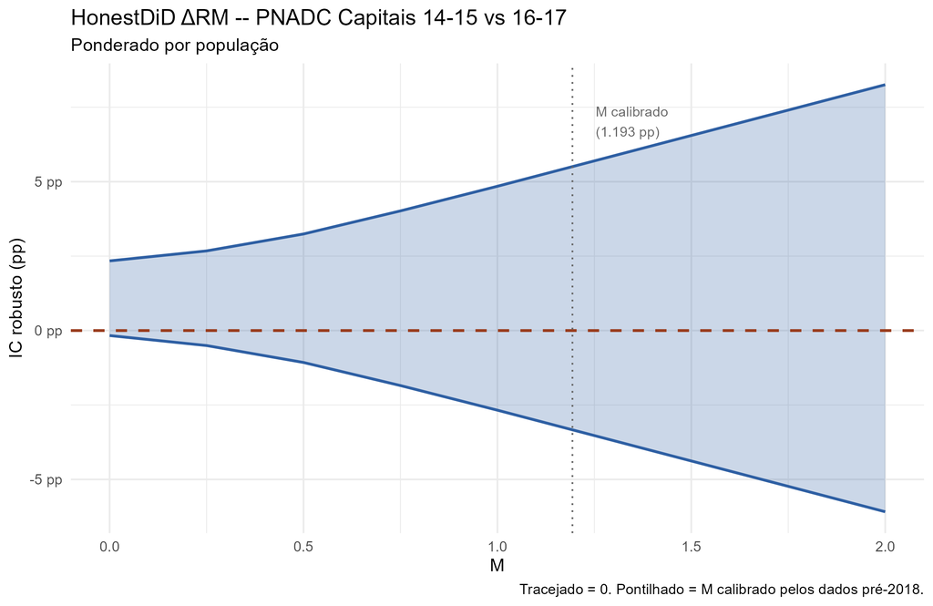

### Robustez (14-15 vs 17-18)

```r
if (!is.null(honestdid_capital$hd_1718)) {
  cat(sprintf("M calibrado: %.4f pp (máxima variação observada no pré-período)\n",
              honestdid_capital$hd_1718$M_cal))
}
```

```
## M calibrado: 1.1466 pp (máxima variação observada no pré-período)
```

```r
if (!is.null(honestdid_capital$hd_1718))
  tab_honestdid(honestdid_capital$hd_1718$rm,
                "HonestDiD ΔRM — PNADC Capitais, 14-15 vs 17-18. Valores em pp.")
```

HonestDiD ΔRM — PNADC Capitais, 14-15 vs 17-18. Valores em pp.

| lb | ub | method | Delta | Mbar |
| --- | --- | --- | --- | --- |
| -0.0914 | 3.4563 | C-LF | DeltaRM | 0.00 |
| -0.4206 | 3.7855 | C-LF | DeltaRM | 0.25 |
| -1.0424 | 4.4073 | C-LF | DeltaRM | 0.50 |
| -1.9202 | 5.2851 | C-LF | DeltaRM | 0.75 |
| -2.8711 | 6.2360 | C-LF | DeltaRM | 1.00 |
| -3.8587 | 7.2236 | C-LF | DeltaRM | 1.25 |
| -4.8462 | 8.2111 | C-LF | DeltaRM | 1.50 |
| -5.8703 | 9.2352 | C-LF | DeltaRM | 1.75 |
| -6.8944 | 10.2593 | C-LF | DeltaRM | 2.00 |

```r
if (!is.null(honestdid_capital$hd_1718))
  tab_honestdid(honestdid_capital$hd_1718$sm,
                "HonestDiD ΔSD — PNADC Capitais, 14-15 vs 17-18. Valores em pp.")
```

HonestDiD ΔSD — PNADC Capitais, 14-15 vs 17-18. Valores em pp.

| lb | ub | method | Delta | M |
| --- | --- | --- | --- | --- |
| -0.5303 | 3.8952 | C-LF | DeltaSD | 0.0000 |
| -0.9172 | 4.2490 | C-LF | DeltaSD | 0.4300 |
| -1.2829 | 4.6147 | C-LF | DeltaSD | 0.8599 |
| -1.6642 | 4.9926 | C-LF | DeltaSD | 1.2899 |
| -2.0609 | 5.3825 | C-LF | DeltaSD | 1.7199 |
| -2.4323 | 5.7844 | C-LF | DeltaSD | 2.1498 |
| -2.8592 | 6.1984 | C-LF | DeltaSD | 2.5798 |
| -3.2590 | 6.6244 | C-LF | DeltaSD | 3.0098 |
| -3.6725 | 7.0190 | C-LF | DeltaSD | 3.4398 |

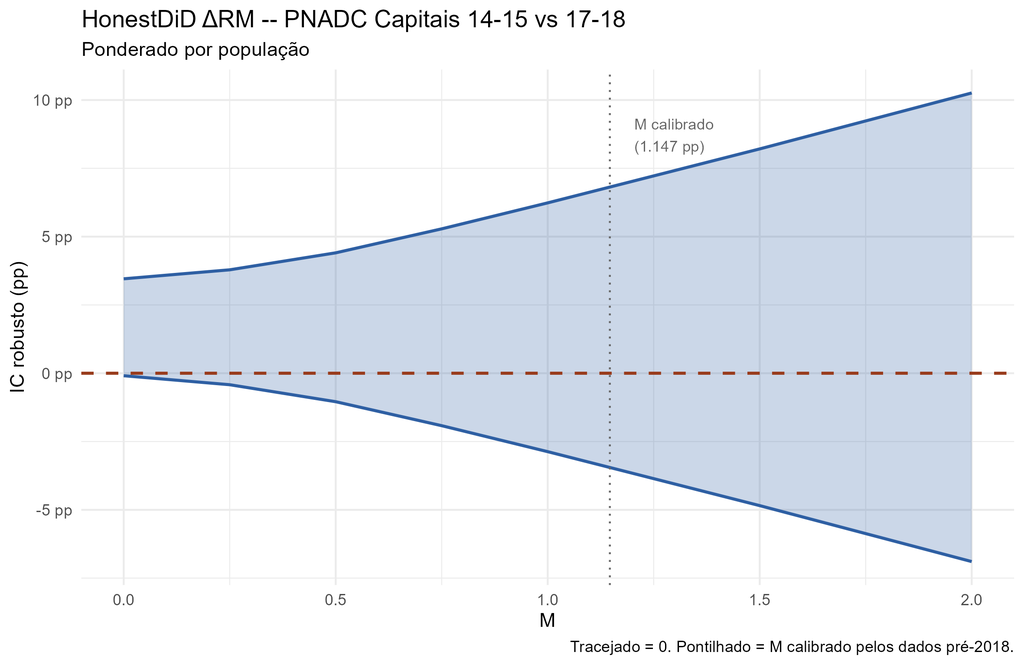

## Referências

- Callaway & Sant’Anna (2021). *Journal of Econometrics*, 225(2), 200–230.
- Rambachan & Roth (2023). *Review of Economic Studies*, 90(5), 2555–2591.